# Performance comparison with other functional diversity packages

This vignette presents some performance tests ran between `fundiversity` and other functional diversity packages. Note that to avoid the dependency on other packages, this vignette is [**pre-computed**](https://ropensci.org/technotes/2019/12/08/precompute-vignettes/).

# Other packages to compute FD indices

## Main functions

**`FD::dbFD()`** is probably the most known function to compute functional diversity indices. It comes from the `FD` package proposed by Laliberté, Legendre, and Shipley (2014). It can compute many indices: functional richness, Rao’s quadratic entropy, community-weighted mean, functional divergence, functional dispersion, and functional group richness. This swiss-army knife of functional diversity indices has many options and compute several indices in a single run.

**`adiv::QE()`** comes from the `adiv` package which proposes a toolkit to analyze biodiversity (Pavoine 2020). This function computes Rao’s quadratic entropy.

**`SYNCSA::rao.diversity()`** comes from `SYNCSA` package which proposes a simulation framework for meta-communities (Debastiani and Pillar 2012). The function computes Rao’s quadratic entropy as well as functional redundancy.

**`mFD::alpha.fd.hill()`** comes from the `mFD` package which offers a coherent framework to work with functional spaces and perform quality checks, diagnostic plots, as well as computing many functional diversity indices.

## Benchmark between packages

We will now benchmark the functions included in `fundiversity` with the corresponding function in other packages using the `microbenchmark::microbenchmark()` function.

```r
tictoc::tic()
library(fundiversity)
data("traits_birds", package = "fundiversity")
data("site_sp_birds", package = "fundiversity")

dist_traits_birds <- dist(traits_birds)
```

With the fairly small (~220 species, 8 sites, 4 traits) provided dataset in `fundiversity`:

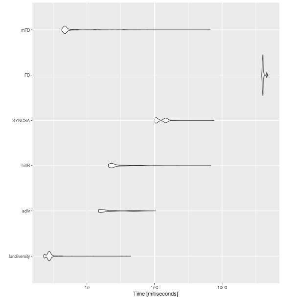

Performance comparison in computing Rao’s quadratic entropy between `fundiversity` and other packages

```r
pkg_bench <- microbenchmark::microbenchmark(
  fundiversity = {
    fundiversity::fd_raoq(traits = NULL, site_sp_birds, dist_traits_birds)
  },
  adiv = {
    adiv::QE(site_sp_birds, dis = dist_traits_birds)
  },
  hillR = {
    hillR::hill_func(site_sp_birds, dist_traits_birds, traits_as_is = TRUE)[1, ]
  },
  SYNCSA = {
    SYNCSA::rao.diversity(site_sp_birds,
                          phylodist = as.matrix(dist_traits_birds),
                          standardize = FALSE)$PhyRao
  },
  FD = {
    suppressMessages(
      FD::dbFD(x = dist_traits_birds, a = site_sp_birds, stand.x = FALSE,
               calc.FRic = TRUE, calc.CWM = FALSE, calc.FDiv = FALSE,
               calc.FGR = FALSE, m = "max", stand.FRic = FALSE,
               messages = FALSE))
  },
  mFD = {
    mFD::alpha.fd.hill(site_sp_birds, dist_traits_birds, q = 2, tau = "max",
                       details_returned = FALSE)
  },
  times = 500
)

ggplot2::autoplot(pkg_bench)
```

```r
pkg_bench
```

```
#> Unit: milliseconds
#>          expr         min          lq        mean      median          uq       max neval  cld
#>  fundiversity    2.287913    2.630710    3.089326    2.762887    2.891716   44.3695   500 a
#>          adiv   14.906173   15.719250   26.646127   16.773885   32.032801  103.7893   500  b
#>         hillR   20.696094   22.602998   32.499789   24.343631   33.482000  680.6541   500  b
#>        SYNCSA  101.301958  105.161422  129.325061  118.840921  146.598844  758.1414   500   c
#>            FD 3849.335158 3956.290358 4053.866622 4000.860019 4050.856521 4778.5860   500    d
#>           mFD    4.251853    4.609947   11.588040    4.842196    5.545768  665.1295   500 a
```

# Benchmark within `fundiversity`

We now proceed to the performance evaluation of functions within `fundiversity` with datasets of increasing sizes.

## Increasing the number of species

```r
make_more_sp <- function(n) {
  traits <- do.call(rbind, replicate(n, traits_birds, simplify = FALSE))
  row.names(traits) <- paste0("sp", seq_len(nrow(traits)))

  site_sp <- do.call(cbind, replicate(n, site_sp_birds, simplify = FALSE))
  colnames(site_sp) <- paste0("sp", seq_len(ncol(site_sp)))

  list(tr = traits, si = site_sp)
}

null_sp_1000   <- make_more_sp(5)
null_sp_10000  <- make_more_sp(50)
null_sp_100000 <- make_more_sp(500)
```

### Functional Richness

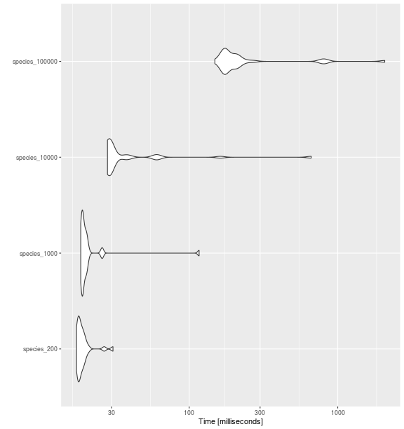

Performance comparison of `fd_fric()` with increasing number of species.

```r
bench_sp_fric <- microbenchmark::microbenchmark(
  species_200    = fd_fric(     traits_birds, site_sp_birds),
  species_1000   = fd_fric(  null_sp_1000$tr, null_sp_1000$si),
  species_10000  = fd_fric( null_sp_10000$tr, null_sp_10000$si),
  species_100000 = fd_fric(null_sp_100000$tr, null_sp_100000$si),
  times = 30
)

ggplot2::autoplot(bench_sp_fric)
```

```r
bench_sp_fric
```

```
#> Unit: milliseconds
#>            expr       min        lq      mean    median        uq        max neval cld
#>     species_200  17.43907  17.86243  19.25563  18.36463  19.43581   30.67592    30  a
#>    species_1000  18.61623  18.95761  23.12715  19.33508  20.27961  116.57998    30  a
#>   species_10000  28.16377  28.72545  58.63922  29.44426  37.00387  662.93365    30  a
#>  species_100000 148.85628 172.34064 313.60939 180.87062 212.01963 2071.42395    30   b
```

### Functional Divergence

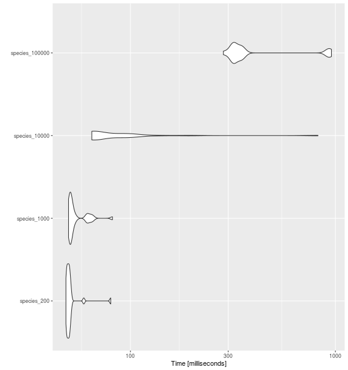

Performance comparison of `fd_fdiv()` with increasing number of species.

```r
bench_sp_fdiv <- microbenchmark::microbenchmark(
  species_200    = fd_fdiv(     traits_birds, site_sp_birds),
  species_1000   = fd_fdiv(  null_sp_1000$tr, null_sp_1000$si),
  species_10000  = fd_fdiv( null_sp_10000$tr, null_sp_10000$si),
  species_100000 = fd_fdiv(null_sp_100000$tr, null_sp_100000$si),
  times = 30
)

ggplot2::autoplot(bench_sp_fdiv)
```

```r
bench_sp_fdiv
```

```
#> Unit: milliseconds
#>            expr       min        lq      mean    median        uq       max neval cld
#>     species_200  48.44905  49.03244  51.10591  49.83909  50.63842  80.15223    30  a
#>    species_1000  49.90169  50.47038  54.57637  51.34235  54.04361  81.71650    30  a
#>   species_10000  64.80198  65.77591 106.63771  66.45525  96.01833 822.19062    30  a
#>  species_100000 284.15498 316.50850 448.10526 328.81308 358.02843 956.35379    30   b
```

### Rao’s Quadratic Entropy

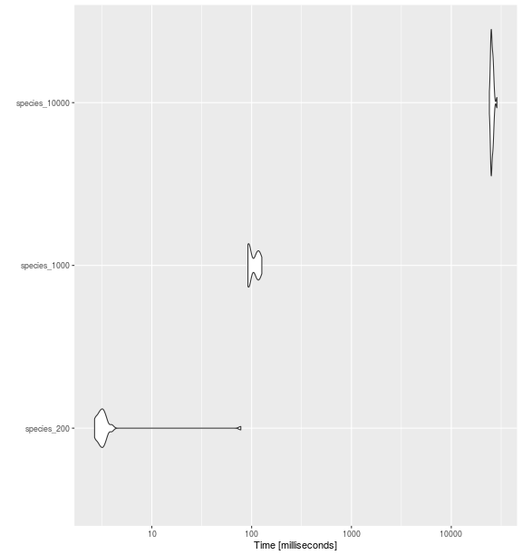

Performance comparison of `fd_raoq()` with increasing number of species.

```r
bench_sp_raoq <- microbenchmark::microbenchmark(
  species_200    = fd_raoq(     traits_birds, site_sp_birds),
  species_1000   = fd_raoq(  null_sp_1000$tr, null_sp_1000$si),
  species_10000  = fd_raoq( null_sp_10000$tr, null_sp_10000$si),
  times = 30
)

ggplot2::autoplot(bench_sp_raoq)
```

```r
bench_sp_raoq
```

```
#> Unit: milliseconds
#>           expr          min           lq         mean       median           uq         max neval cld
#>    species_200     2.670416     2.943108     5.652929     3.171312     3.366178    77.94491    30  a
#>   species_1000    91.829330    92.648495   104.365654    94.808870   116.528429   126.52938    30  a
#>  species_10000 24088.575237 24965.084344 25589.177876 25347.518500 26110.519379 28657.24666    30   b
```

### Functional Evenness

```r
bench_sp_feve <- microbenchmark::microbenchmark(
  species_200    = fd_feve(     traits_birds, site_sp_birds),
  species_1000   = fd_feve(  null_sp_1000$tr, null_sp_1000$si),
  species_10000  = fd_feve( null_sp_10000$tr, null_sp_10000$si),
  times = 30
)
```

[output not shown]

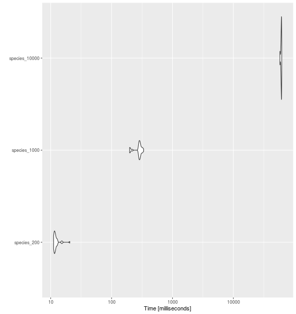

Performance comparison of `fd_feve()` with increasing number of species.

```r
ggplot2::autoplot(bench_sp_feve)
```

```r
bench_sp_feve
```

```
#> Unit: milliseconds
#>           expr         min          lq        mean      median          uq         max neval cld
#>    species_200    11.17215    11.44301    12.33728    11.79237    12.24989    20.59761    30  a
#>   species_1000   197.85067   279.95442   280.47473   289.50154   297.68343   336.33779    30  a
#>  species_10000 58136.53352 60618.48446 60999.92341 61352.07935 61751.75521 62372.93708    30   b
```

### Comparing between indices

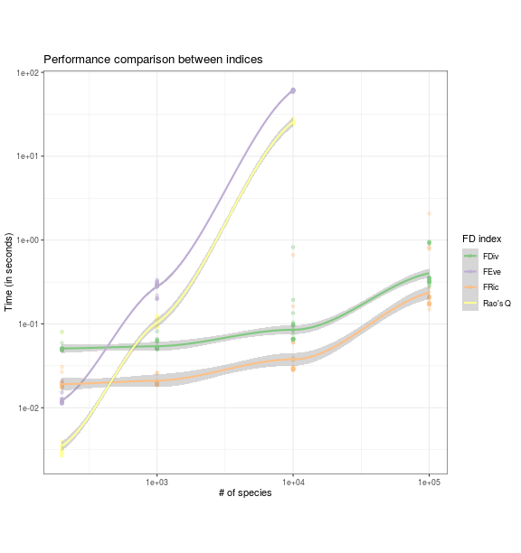

Performance comparison between functions for distinct indices in `fundiversity` with increasing number of species. Smoothed trend lines and standard error envelopes ares shown.

```r
all_bench_sp <- list(fric = bench_sp_fric,
                     fdiv = bench_sp_fdiv,
                     raoq = bench_sp_raoq,
                     feve = bench_sp_feve) %>%
  bind_rows(.id = "fd_index") %>%
  mutate(n_sp = gsub("species_", "", expr) %>%
           as.numeric())

all_bench_sp %>%
  ggplot(aes(n_sp, time * 1e-9, color = fd_index)) +
  geom_point(alpha = 1/3) +
  geom_smooth() +
  scale_x_log10() +
  scale_y_log10() +
  scale_color_brewer(type = "qual",
                     labels = c(fric = "FRic", fdiv = "FDiv", raoq = "Rao's Q",
                                feve = "FEve")) +
  labs(title = "Performance comparison between indices",
       x = "# of species", y = "Time (in seconds)",
       color = "FD index") +
  theme_bw() +
  theme(aspect.ratio = 1)
```

## Increasing the number of sites

```r
make_more_sites <- function(n) {
  site_sp <- do.call(rbind, replicate(n, site_sp_birds, simplify = FALSE))
  rownames(site_sp) <- paste0("s", seq_len(nrow(site_sp)))

  site_sp
}

site_sp_100   <- make_more_sites(12)
site_sp_1000  <- make_more_sites(120)
site_sp_10000 <- make_more_sites(1200)
```

### Functional Richness

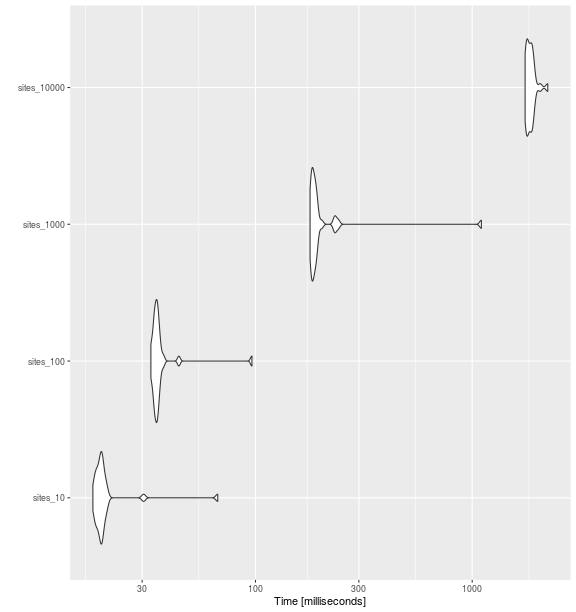

Performance comparison of `fd_fric()` with increasing number of sites.

```r
bench_sites_fric = microbenchmark::microbenchmark(
  sites_10    = fd_fric(traits_birds, site_sp_birds),
  sites_100   = fd_fric(traits_birds, site_sp_100),
  sites_1000  = fd_fric(traits_birds, site_sp_1000),
  sites_10000 = fd_fric(traits_birds, site_sp_10000),
  times = 30
)

ggplot2::autoplot(bench_sites_fric)
```

```r
bench_sites_fric
```

```
#> Unit: milliseconds
#>         expr        min         lq       mean     median         uq        max neval cld
#>     sites_10   17.77558   18.58610   21.18691   19.36247   19.83560   66.98525    30 a
#>    sites_100   32.91720   34.17783   37.24440   35.02940   35.70176   96.30081    30 a
#>   sites_1000  178.65317  181.95299  221.38235  186.83763  191.94836 1102.60246    30  b
#>  sites_10000 1754.78248 1785.23758 1857.44765 1846.69689 1890.84202 2232.53853    30   c
```

### Functional Divergence

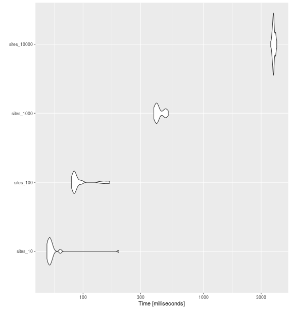

Performance comparison of `fd_fdiv()` with increasing number of sites.

```r
bench_sites_fdiv = microbenchmark::microbenchmark(
  sites_10    = fd_fdiv(traits_birds, site_sp_birds),
  sites_100   = fd_fdiv(traits_birds, site_sp_100),
  sites_1000  = fd_fdiv(traits_birds, site_sp_1000),
  sites_10000 = fd_fdiv(traits_birds, site_sp_10000),
  times = 30
)

ggplot2::autoplot(bench_sites_fdiv)
```

```r
bench_sites_fdiv
```

```
#> Unit: milliseconds
#>         expr        min         lq       mean     median         uq       max neval  cld
#>     sites_10   50.17003   51.88956   58.73887   53.34411   55.25329  197.9635    30 a
#>    sites_100   80.40664   84.18102   97.06916   84.94270   94.98646  166.4284    30  b
#>   sites_1000  386.55725  402.17618  429.92229  413.10485  469.88815  509.0017    30   c
#>  sites_10000 3603.94346 3757.78241 3813.13545 3800.30931 3866.23993 4042.1464    30    d
```

### Rao’s Quadratic Entropy

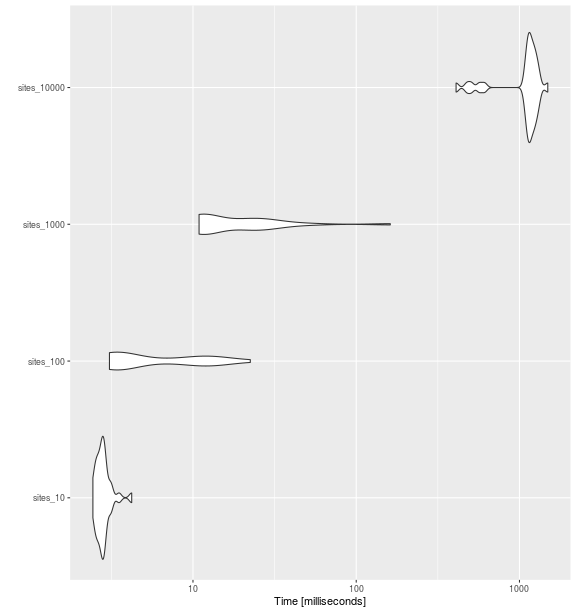

Performance comparison of `fd_raoq()` with increasing number of sites.

```r
bench_sites_raoq = microbenchmark::microbenchmark(
  sites_10    = fd_raoq(traits = NULL, site_sp_birds, dist_traits_birds),
  sites_100   = fd_raoq(traits = NULL, site_sp_100,   dist_traits_birds),
  sites_1000  = fd_raoq(traits = NULL, site_sp_1000,  dist_traits_birds),
  sites_10000 = fd_raoq(traits = NULL, site_sp_10000, dist_traits_birds),
  times = 30
)

ggplot2::autoplot(bench_sites_raoq)
```

```r
bench_sites_raoq
```

```
#> Unit: milliseconds
#>         expr       min          lq        mean      median          uq         max neval cld
#>     sites_10   2.43763    2.618498    2.835577    2.786454    2.899721    4.214509    30  a
#>    sites_100   3.07880    3.293774    7.170445    4.036631   11.673449   22.447060    30  a
#>   sites_1000  10.89814   11.346314   23.568799   12.680631   24.267842  161.626134    30  a
#>  sites_10000 408.95982 1106.958572 1084.559002 1157.547212 1230.670102 1490.536708    30   b
```

### Functional Evenness

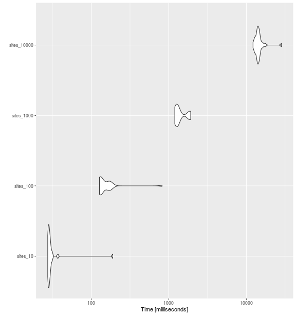

Performance comparison of `fd_feve()` with increasing number of sites

```r
bench_sites_feve = microbenchmark::microbenchmark(
  sites_10    = fd_feve(traits = NULL, site_sp_birds, dist_traits_birds),
  sites_100   = fd_feve(traits = NULL, site_sp_100,   dist_traits_birds),
  sites_1000  = fd_feve(traits = NULL, site_sp_1000,  dist_traits_birds),
  sites_10000 = fd_feve(traits = NULL, site_sp_10000, dist_traits_birds),
  times = 30
)

ggplot2::autoplot(bench_sites_feve)
```

```r
bench_sites_feve
```

```
#> Unit: milliseconds
#>         expr         min          lq       mean      median         uq        max neval cld
#>     sites_10    27.47611    27.95555    34.4079    28.74399    29.6761   189.6112    30 a
#>    sites_100   127.61540   130.15233   168.1676   132.48679   168.9531   819.7361    30 a
#>   sites_1000  1195.25759  1268.52395  1432.1127  1287.19147  1839.7692  1916.8058    30  b
#>  sites_10000 12192.27871 13661.60213 14675.2386 14058.28719 14820.7077 28405.1799    30   c
```

### Comparing between indices

[figure not shown]

Performance comparison between functions for distinct indices in `fundiversity` with increasing number of sites. Smoothed trend lines and standard error envelopes ares shown.

```r
all_bench_sites <- list(fric = bench_sites_fric,
                        fdiv = bench_sites_fdiv,
                        raoq = bench_sites_raoq,
                        feve = bench_sites_feve) %>%
  bind_rows(.id = "fd_index") %>%
  mutate(n_sites = gsub("sites", "", expr) %>%
           as.numeric())

all_bench_sites %>%
  ggplot(aes(n_sites, time * 1e-9, color = fd_index)) +
  geom_point(alpha = 1/3) +
  geom_smooth() +
  scale_x_log10() +
  scale_y_log10() +
  scale_color_brewer(type = "qual",
                     labels = c(fric = "FRic", fdiv = "FDiv", raoq = "Rao's Q",
                                feve = "FEve")) +
  labs(title = "Performance comparison between indices",
       x = "# of sites", y = "Time (in seconds)",
       color = "FD index") +
  theme_bw() +
  theme(aspect.ratio = 1)
```

# References

Chao, Anne, Chun-Huo Chiu, and Lou Jost. 2014. “Unifying Species Diversity, Phylogenetic Diversity, Functional Diversity, and Related Similarity and Differentiation Measures Through Hill Numbers.” *Annual Review of Ecology, Evolution, and Systematics* 45 (1): 297–324. https://doi.org/10.1146/annurev-ecolsys-120213-091540.

Debastiani, Vanderlei J., and Valério D. Pillar. 2012. “SYNCSA Tool for Analysis of Metacommunities Based on Functional Traits and Phylogeny of the Community Components.” *Bioinformatics* 28 (15): 2067–68. https://doi.org/10.1093/bioinformatics/bts325.

Laliberté, Etienne, Pierre Legendre, and Bill Shipley. 2014. *FD: Measuring Functional Diversity from Multiple Traits, and Other Tools for Functional Ecology*.

Li, Daijiang. 2018. “hillR: Taxonomic, Functional, and Phylogenetic Diversity and Similarity Through Hill Numbers.” *Journal of Open Source Software* 3 (31): 1041. https://doi.org/10.21105/joss.01041.

Pavoine, Sandrine. 2020. “adiv: An r Package to Analyse Biodiversity in Ecology.” *Methods in Ecology and Evolution* 11 (9): 1106–12. https://doi.org/10.1111/2041-210X.13430.